# Random Variables

Seoncheol Park

11/29/2019

다음의 책을 참고하였다.

- Probability and Measure, Patrick Billingsley (PB)
- [Probability, Theory and Examples, Rick Durrett](https://services.math.duke.edu/~rtd/PTE/PTE5_011119.pdf) (RD)
- Essential of Probability Theory for Statistician
- Probability Essentials, Jean Jacod and Philip Protter (JP)
- Probability for Statisticians, Galen R. Shorack (GS)
- Probability: A Graduate Course, Allan Gut (AG)
- Analysis, Measure, and Probability: A visual introduction
- Counterexamples in Probability, Jordan M. Stoyanov (JS)

# 확률변수

**확률변수(random variable)**의 예로는 카드를 생각해 볼 수 있다. 확률변수 $X=X(\omega)$는 실변수 함수로 정의역은 $\Omega$이다. 각각의 $\omega$가 특정한 5장의 카드 집합을 나타낸다고 할 때 $X(\omega)=I\{\omega$가 네 개의 에이스를 가지고 있음$\}$이라고 정의한다면 $X(\omega)$는 random variable이다.

**Definition 1 (가측)** $(\Omega_{1}, \mathcal{F}_{1})$, $(\Omega_{2}, \mathcal{F}_{2})$가 두 가측공간(measurable)이라고 할 때, 함수 $X:\Omega_{1} \rightarrow \Omega_{2}$가 임의의 집합 $E\in \mathcal{F}_{2}$에 대해 집합 $X^{-1}(E)$이
$$X^{-1}(E)=\{ \omega \in \Omega_{1}: X(\omega) \in E\} \mathcal{F}_{1}$$
(또는 위 조건을 $X^{-1}(\mathcal{F}_{2})\in \mathcal{F}_{1})$) 일 때 $X$가 **가측(measurable)**이라고 한다. (또는 $\mathcal{F}_{1}$-가측 이라고도 부른다.)

**Definition 2 (확률변수)** $(\Omega, \mathcal{F}, P)$가 확률공간(probability space)이라고 하자. 그러면 어떤 실변수 함수
$$X:\Omega \rightarrow \mathbb{R}$$
가 $(\Omega, \mathcal{F})$에서 $(\mathbb{R}, \mathcal{B})$로 가는 가측함수(measurable function)일 때(여기서 $\mathcal{B}$는 $\mathbb{R}$에서의 보렐 시그마-체) 이 $X$를 **확률변수(random variable)**라고 부른다.

다음 그림은 $(\Omega, \mathcal{F}, P)= ((0,1), \mathcal{B}_{(0,1)}, \mu_{L})$에서의 확률변수 $X(\omega) = \frac{1}{\omega(1-\omega)}$의 **역상(inverse image)** 개념을 묘사한 것이다. 이 때 보렐 집합 $B=\{ (6.25, \infty)\cup \{4\} \}$이며, $X^{-1}(B)=\{ (0,0.2)\cup (0.8,1)\cup \{0.5\} \}$이며 이는 $\mathcal{B}_{(0,1)}$안에 있다.

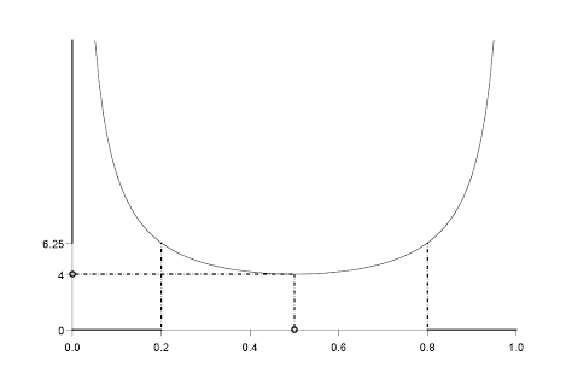

Figure 1: 역상의 예.

**Example 1 (확률변수의 예)** $\Omega=[0,1]$, $\mathcal{F}=\mathcal{B}_{[0,1]}$이며 $\Omega$의 부분집합이라고 하자. 그러면

1. $X_{1}(\omega)\equiv=c$.
2. $X_{2}(\omega)=I(\omega \leq 1/2)$.
3. $X_{3}(\omega) = \omega$.

위 $X_{1}$, $X_{2}$, $X_{3}$은 모두 확률변수이다. $B\in\mathcal{B}$이면 $B$가 $c$를 포함할 경우 $X_{1}^{-1}(B)=\Omega\in\mathcal{F}$, 그렇지 않을 경우 $X_{1}^{-1}(B)=\emptyset\in\mathcal{F}$이므로 $X_{1}$는 $\mathcal{F}$-가측이다. 또한
$$X_{2}^{-1}(B) :=
\begin{cases}
\emptyset\in\mathcal{F} & \text{if $B$ contains neither 0 nor 1} \\
\Omega\in\mathcal{F} & \text{if $B$ contains both 0 and 1} \\
[1/2,1]\in\mathcal{F} & \text{if $B$ contains 1, but not 0} \\
[0,1/2]\in\mathcal{F} & \text{if $B$ contains 0, but not 1} \\
\end{cases}$$
이며 따라서 $X_{2}$는 $\mathcal{F}$-가측이다. $B\in\mathcal{B}$일 떄 $X_{3}^{-1}(B)=B\cap [0,1] \in \mathcal{B}_{[0,1]}\in\mathcal{F}$이므로 $X_{3}(\omega)$또한 확률변수다.

앞선 예제에서 $X$가 확류변수임을 보이기 위해 $X^{-1}(\mathcal{B})=\{ X^{-1}(B), B\in\mathcal{B}\}$를 계산하였다. 이 때 $\mathcal{F}$의 부분집합인 $X^{-1}(\mathcal{B})$는 $X$를 가측으로 만드는 관점에서 가장 작은 시그마-장이된다.

**Definition 3 (확률변수로부터 생성되는 시그마-장)** 만약 $X$가 확률변수라면, $X$를 가측으로 만드는 가장 작은 시그마-장, 즉 $X^{-1}(\mathcal{B})=\{ X^{-1}(B), B\in\mathcal{B}\}$를 $X$로부터 생성되는 시그마-장이라 하고 $\sigma(X)$라 표기한다.

앞선 예제에서 확률변수 $X$에 대해 사건 $F\in \sigma(X)$을 결정할 수 있다. 예를 들면, $\sigma(X_{1})=\{ \emptyset, [0,1] \}\subset \{ \emptyset, [0,1], [0,1/2), [1/2,1] \}=\sigma(X_{2})$이다. 이 말은 $X_{2}$가 $X_{1}$보다 $\omega$에 대해 더 많은 정보를 준다는 것을 말해준다. $X_{1}$은 어떤 사건이 일어났는지 안일어났는지만 얘기해주지만, $X_{2}$는 $\omega$가 1/2보다 큰지 작은지도 알려주는 것이다. 또한 $\sigma(X_{2})\subset\sigma(X_{3})$이므로 $X_{3}$은 $X_{2}$보다 많은 정보를 주는 것이다. 실제로 $X_{3}$은 실험에서 나온 $\omega$의 정확한 값을 알려준다.

**Definition 4 (보렐 측도가능과 르베그 측도가능 함수)** 어떤 함수 $f:\mathbb{R}^{k}\rightarrow \mathbb{R}$을

1. 1차원 보렐 집합 $B\in\mathcal{B}$에 대해 $f^{-1}*B$ 가 $k$차원 보렐 집할이 될 경우 **보렐 측도가능(Borel measurable)** 또는 **보렐 함수(Borel function)**이라고 부른다.
2. 1차원 르베그 집합 $B\in\mathcal{B}$에 대해 $f^{-1}*B$ 가 $k$차원 르베그 집할이 될 경우 **르베그 측도가능(Lebesgue measurable)** 또는 **르베그 함수(Lebesguel function)**이라고 부른다.

참고로 보렐 함수의 집합은 모든 연속함수들을 포함, 실전에서 관심있어 하는 함수들을 거의 포함하는 큰 class이다.

The intuition from regarding $\sigma$-fields generated by random variables as measures of their information about $\omega$ suggest that if $Y$ is a function of $X$, the $\sigma$-field generated by $Y$ must be contained in the $\sigma$-field generated by $X$. After all, if we know $X$, then we know $Y$, so $Y$ must be less informative than $X$. Of course, if $Y=f(X)$ and $X=g(Y)$ for Borel functions $f$ and $g$, then $X$ and $Y$ should be equally informative about $\omega$.

**Proposition 1 (Functions of random variables generate smaller sigma-fields)** Let $X(\omega)$ be a random variable and $Y(\omega)= f(X(\omega))$ for some Borel function $f: \mathbb{R} \rightarrow \mathbb{R}$. Then

1. $Y$ is a random variable.
2. $\sigma(Y)\subset \sigma(X)$.
3. If, additionally, $X=g(Y)$ for a Borel function $g$, then $\sigma(X) = \sigma(Y)$.

**Exercise 1** Prove above.

확률변수 $X$가 $\mathcal{F}$-measurable 함을 다룰 때 가장 주의해야 할 점은 항상 모든 Borel set $\mathcal{B}$에 대해 $X^{-1}(\mathcal{B})$를 고려해야 한다는 점이다. 그래서 $X$가 $\mathcal{F}$-measurable 함을 보이는 것은 성가신 일인데, 다음의 proposition이 $\mathcal{F}$-measurable 함에 대한 좀 더 간단한 조건을 보여준다.

**Proposition 2 (A simpler condition for F-measurability)** A necessary and sufficient condition for $\mathcal{F}$-measurability of $X(\omega)$ is that $X^{-1}(-\infty, x]\in\mathcal{F}$ for each $x\in \mathbb{R}$. The statement remains true if we replace $(-\infty, x]$ by $(-\infty, x)$.

*Proof.* - (necessity) Follows from the fact that $(-\infty, x]$ is a Borel set of $\mathbb{R}$.

- (sufficiency) Assume that $X^{-1}(-\infty, x] \in\mathcal{F}$ for each $x$, and let $\mathcal{A}$ be the collection of Borel sets such that $X^{-1}(A)\in\mathcal{F}$. We can show that $\mathcal{A}$ is a $\sigma$-field. (Prove this!) Therefore, $\mathcal{A}$ is a $\sigma$-field containing all intervals $(-\infty, x]$, $x\in \mathbb{R}$. This means $\mathcal{A}$ contains $\sigma \{(-\infty,x], x\in \mathbb{R} \}$, the smallest $\sigma$-field containing $\{(-\infty, x], x\in\mathbb{R} \}$. But $\sigma\{(-\infty, x], x\in \mathbb{R}\}$ is the Borel $\sigma$-field $\mathcal{B}$. Therefore, $\mathcal{B}\subset\mathcal{A}$. That is, $X$ is $\mathcal{F}$-measurable by the definition.
- 만약 $(-\infty, x]$를 $(-\infty, x)$로 바꾸고 싶으면 $X^{-1}(-\infty, x] = \cap_{n}X^{-1}(-\infty, x + \frac{1}{n})\in\mathcal{F}$ for all $x\in \mathbb{R}$ 임을 활용하면 된다.

Proposition 2 을 활용해 연속함수가 보렐-가측이라는 것을 보일 수 있다.

**Proposition 3 (Continuous implies Borel)** A continuous function $f:\mathbb{R}^{k}\rightarrow \mathbb{R}$ is a Borel function.

*Proof.* Proposition 2 에 의해 $f^{-1}(-\infty, x)\in \mathbb{B}^{k}$ for each $x$임을 보이는 것만으로도 충분하다. 그런데 $(-\infty, x)$는 열린 집합이므로, $f^{-1}(-\infty, x)$ 또한 $\mathbb{R}^{k}$의 open set이 되므로 보렐 집합은 모든 open, closed set을 갖고 있다는 사실에 의해 증명이 끝난다.

### 확률변수들에 의해 유도되는 확률측도

지금까지는 확률변수에 의해 생성되는 $\sigma$-field에 초점을 맞추었다면 이제는 확률변수와 연관된 확률측도에 집중해보자. Probabilities of events involving $X$ are calculated using the probability measure $P$ on the original probability space $(\Omega, \mathcal{F}, P)$.

**Example 2** Let $(\Omega, \mathcal{F}, P) = ([0,1],\mathcal{B}_{[0,1]}, \mu_{L})$, where $\mu_{L}$: Lebesgue measure on $[0,1]$. 만약 $X(\omega)= -\text{ln}(\omega)$, then the probability that $X\leq x$ is $\mu_{L}\{\omega: X(\omega)\leq x \}=\mu_{L}\{\omega: \omega \geq \exp(-x) \} = 1- \exp(-x)$.

Likewise, the probability that $X$ is in the interval $(a,b)$ is $\mu_{L}\{\omega: a < X(\omega) < b \} = \mu_{L}\{\omega: \exp(-b) < \omega < \exp(-a) \} = \exp(-a) - \exp(-b)$.

우리는 $X\leq x$의 확률을 안다면, any Borel set $B$의 확률을 계산할 수 있음을 안다. 정리하면, the random variable on the original probability space induces a new probability measure $P'$ on $R$, in this case defined by the exponential distribution with parameter 1.

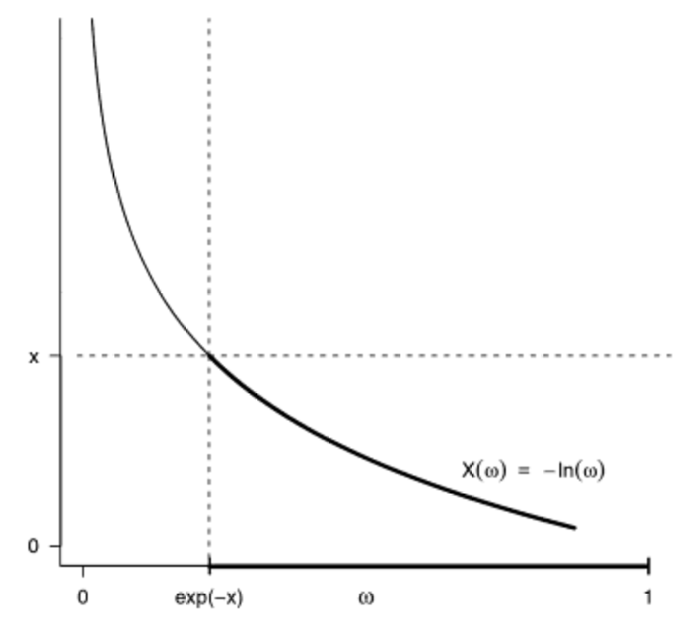

Figure 2: Generating exponential distribution.

**Proposition 4 (확률변수에 의해 유도되는 학률측도)** A random variable $X$ on $(\Omega, \mathcal{F}, P)$ induces a probability measure $P'$ on the probability space $(\mathbb{R}, \mathcal{B}, P')$ through $P'(B)=P\{ X^{-1}(B) \} = P\{\omega : X(\omega)\in B \}$.

**Exercise 2** 위 따름정리에서 $P'$가 확률측도임을 보이시오.

To emphasize the correspondence between the original and induced probability spaces, we sometimes write $X: (\Omega, \mathcal{F})\rightarrow (R,\mathcal{B})$. This does **not** mean that $X(F)\in\mathcal{B}$ for each $F\in\mathcal{F}$; this need not hold. Rather, it means that $X^{-1}(B)\in\mathcal{F}$ for each $B\in\mathcal{B}$ (i.e., $X$ is $\mathcal{F}$-measurable).

Notice that the original probability measure is on a probability space of arbitrary objects. For example, below Figure illustrates the correspondence between the original and induced probability measures when $\Omega$ is the collection of trigonometric functions $\Omega = \{ \cos (1x), \cos (2x), \cos (3x), \ldots \}$, $P=\{\frac{1}{2}, \frac{1}{2^2}, \frac{1}{2^3}\}$, and $X(\omega)=\text{ the number of zeros of } \omega \in [0,2\pi]$.

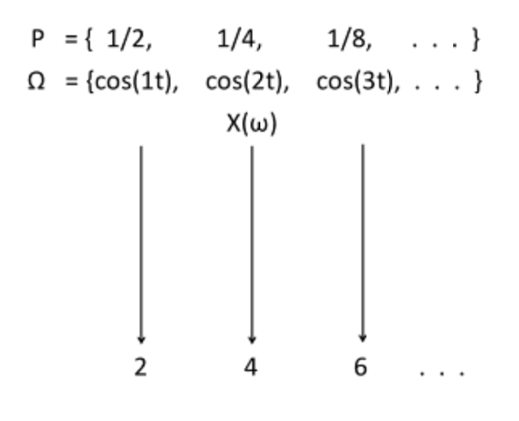

## 확률벡터

### 확률벡터들에 의해 생성되는 $\sigma$-fields

$k$-차원 확률벡터 $(X_1, \ldots, X_k)$는 random variable들의 collection으로 볼 수 있다. 확률변수에 의해 생성되는 $\sigma$-field를 정의했던 것처럼 같은 논리로 확률벡터에 의해 생성되는 $\sigma$-field 또한 정의할 수 있다.

**Definition 5 (Sigma-fields generated by an arbitrary collection of random variables)** The $\sigma$-fields $\sigma \{X_{t}, t\in T \}$ generated by $\{ X_{t}, t\in T\}$, where $T$ is a countable or uncountable index set, is the smallest $\sigma$-field for which each $X_{t}$ is measurable.

즉 $\sigma \{X_{t}, t\in T \}$는 $X_{t}^{-1}(B), B\in\mathcal{B}, t\in T$인 집합들을 모두 포함하는 모든 $\sigma$-field들의 intersection이다.

It is difficult to picture this $\sigma$-field, but as we add more random variables to a collection, the $\sigma$-field generated by the collection enlarges.

For example, with stochastic processes, we observe data $X_t$ over time. The information up to and including time $t$ is $\mathcal{F}_{t} = \sigma(X_s, x\leq t)$. The longer we observe the process, the more information we get, reflected by the fact that $\mathcal{F}_{s} \subset \mathcal{t}$, for $s\leq t$.

1차원에서 우리는 모든 $B\in\mathcal{B}$에 대해 $X^{-1}(B)$를 포함하는 가장 작은 $\sigma$-field $\sigma(X)$가 $\{X^{-1}(B), B\in\mathcal{B}^{1}\}$이 됨을 알았다. 이것은 $\{X^{-1}(B), B\in\mathcal{B}^{1}\}$이 $\sigma$-field가 됨으로부터 유도되었다. 이 논리를 $k$차원으로도 확장시킬 수 있다. $\sigma(X_1, \ldots, X_k)$가 $X_{i}$를 measurable하게 하는 가장 작은 $\sigma$-field라고 하자. 그러면 $\sigma(X_1,\ldots, X_k)$를 다음과 같이 유도할 수 있다.

**Proposition 5 (k차 random vector의 alternative expression)**
$$\begin{align}
\sigma(X_1, \ldots, X_k) &= (X_1, \ldots, X_k)^{-1}(\mathcal{B}^{k})\\
&= \{ (X_1, \ldots, X_k)^{-1}(B), B\in\mathcal{B}^{k} \}\\
&= \{ [\omega: (X_1 (\omega), \ldots, X_{k}(\omega))\in B], B\in\mathcal{B}^{k}\}.
\end{align}$$

*Proof.* 1. 먼저 해야 할 일은 $(X_1, X_2, \ldots, X_k)^{-1}(\mathcal{B}^{k})\subset \sigma(X_1,\ldots, X_k)$임을 보이는 것이다. $\mathcal{C}$를 $k$-차원 보렐 집합 $C$들의 모임으로, 이 $C$들은 $(X_1, X_2, \ldots, X_k)^{-1}(C)\in\sigma(X_1,\ldots, X_k)$임을 만족한다고 하자. $X_1,\ldots, X_k$들이 확률변수이기 때문에, $\mathcal{C}$는 $B_{1}\times B_{2}\times \ldots \times B_{k}$ 형태의 모든 집합들을 포함한다. (이 때 $B_{i}\in\mathcal{B}^{1}$이다.) 더 나아가, $\mathcal{C}$가 $\sigma$-field임을 보일 수 있는데, 따라서 $\mathcal{C}$는 $\{B_{1}\times B_{2}\times \ldots \times B_{k}: B_{i}\in B^{1}, i=1,\ldots, k\}$인 $\mathbb{R}^{k}$에서의 집합들로 생성되는 $\sigma$-field인 $\mathcal{B}^{k}$를 항상 포함하게 된다. 따라서 $(X_1, X_2, \ldots, X_k)^{-1}(\mathcal{B}^{k})\subset \sigma(X_1,\ldots, X_k)$가 성립한다.

2. $(X_1, X_2, \ldots, X_k)^{-1}(\mathcal{B}^{k})$는 $X_{i}$가 measurable한 관점에서 봤을 때의 $\sigma$-field이고, $\sigma(X_1,\ldots, X_k)$는 이러한 $\sigma$-field들 중 가장 작은 $\sigma$-field이다. 그러므로 $(X_1,\ldots, X_k)^{-1}(\mathcal{B}^{k})\supset \sigma(X_1,\ldots, X_k)$가 된다. $(X_1,\ldots, X_k)^{-1}(\mathcal{B}^{k})\subset \sigma(X_1,\ldots, X_k)$이고 $(X_1,X_2,\ldots, X_{k})^{-1}(\mathcal{B}^{k})\supset \sigma(X_1,\ldots, X_k)$이므로 $(X_1, X_2, \ldots, X_k)^{-1}(\mathcal{B}^{k})\subset \sigma(X_1,\ldots, X_k)$ 이다.

1. Suppose that $B$ contains none of the four pairs $(0,0), (0,1), (1,0)$, or $(1,1)$. Then $(X_1, X_2)^{-1}(B) = \emptyset$.
2. Suppose $B$ contains exactly one of the four pairs.
- If $B$ contains only $(0,0)$, then $(X_1, X_2)^{-1}(B)=\{5\}$.
- If $B$ contains only $(0,1)$, then $(X_1, X_2)^{-1}(B)= \{1,3\}$.
- If $B$ contains only $(1,0)$, then $(X_1, X_2)^{-1}(B)= \{4,6\}$.
- If $B$ contains only $(1,1)$, then $(X_1, X_2)^{-1}(B) = \{2\}$.
3. Suppose $B$ contains exactly two of the pairs. Then $(X_1, X_2)^{-1}(B)$ is a union of the corresponding two sets in part 2. The possible unions are $\{2,5\}$, $\{1,2,3\}$, $\{1,3,5\}$, $\{2,4,6\}$, $\{4,5,6\}$, $\{1,3,4,6\}$.
4. Suppose $B$ contains exactly three of the pairs. Then $(X_1, X_2)^{-1}(B)$ is a union of the corresponding two sets in part 2. The possible unions are $\{1,2,3,5\}$, $\{2,4,5,6\}$, $\{1,3,4,5,6\}$.
5. Suppose $B$ contains all of the pairs. Then $(X_1, X_2)^{-1}(B)=\{1,2,3,4,5,6\}$.

이러한 모든 집합들을 고려했을 때, 우리는 $\{\emptyset, \{2\}, \{5\}, \{1,3,\}, \{4,6\},\{2,5\},\{1,2,3\},\{1,3,5\},\{2,4,6\},\{4,5,6\},\{1,3,4,6\},\{1,2,3,5\},\{2,4,5,6\},\{1,2,3,4,6\},\{1,3,4,5,6\},\{1,2,3,4,5,6\}\}$. $X_1$, $X_2$를 따로 고려하는 것보다 $(X_1, X_2)$를 동시에 고려하는 것이 더 많은 정보를 담고 있기 때문에 이 $\sigma$-field 또한 $\sigma(X_1)$, $\sigma(X_2)$를 동시에 포함하게 된다.

### 확률벡터들로 유도되는 확률측도들

$(\Omega, \mathcal{F})$에서의 확률변수가 $(\mathbb{R}, \mathcal{B})$에서의 확률측도 P’를 유도했던 것처럼, 확률벡터 $(X_1,\ldots, X_k)$ 또한 $(\mathbb{R}^{k}, \mathcal{B}^{k})$에서의 확률측도를 유도할 수 있다.

**Proposition 6 (확률벡터는 확률측도를 유도)** 확률벡터 $(X_1, \ldots, X_k)$는 $(\mathbb{R}^{k}, \mathcal{B}^{k})$에서의 확률측도 $P'$를 다음과 같이 유도할 수 있다.

$$\begin{align}
P'(B) &= P \{ (X_1, \ldots, X_k)^{-1}(B) \}\\
&= P\{\omega: (X_1(\omega), \ldots, X_{k}(\omega))\in B \}, B\in \mathcal{B}^{k}.
\end{align}$$

**Example 4** $([0,1],\mathcal{B}_{[0,1]}, \mu_{L})$에서의 확률공간을 생각해보자. $X_{1}(\omega)=\cos (2\pi\omega )$이고 $X_{2}(\omega) = \omega^{3}$이라고 하자. 만약 $P'$를 $(X_1, X_2)$에 의해 유도되는 $(\mathbb{R}^{2}, \mathcal{B}^{2})$에서의 확률측도라고 한다면, 다음의 확률 $P'\{[0,1]\times (\frac{1}{125}, \frac{1}{64}) \}$을 생각해보자. $\cos(2\pi\omega)\in [0,1] \Leftrightarrow [0,\frac{\pi}{2}] \cup [\frac{3\pi}{2}, 2\pi]$임을 생각하자. 그러면 $\omega \in [0,\frac{1}{4}]\cup [\frac{3}{4},1]$이라는 말과 동치다. 따라서 $\omega^{3}\in (\frac{1}{125}, \frac{1}{64}) \Leftrightarrow \omega \in (\frac{1}{5}, \frac{1}{4})$. Therefore,

$$\begin{align}
P'\{[0,1]\time (\frac{1}{125}, \frac{1}{64})\} &= \mu_{L}\{ ([0,\frac{1}{4} \cup [\frac{3}{4},1]) \cup (\frac{1}{5}, \frac{1}{4}) \}\\
&= \mu_{L}(\frac{1}{5}, \frac{1}{4}) = \frac{1}{20}.
\end{align}$$

**Example 5** Let $(\Omega, \mathcal{F}, P)$를 다시 $([0,1],\mathcal{B}_{[0,1]}, \mu_{L})$라고 두고, $X_{1}(\omega) = I\{ \omega \in [0,\frac{1}{2})\}$, $X_{2}(\omega) = I\{ \omega \in (\frac{1}{4}, \frac{3}{4})\}$, $X_{3}(\omega)= I\{\omega \in (\frac{1}{8}, \frac{1}{2}]\}$라고 두자. 만약 $P'$가 $\mathbb{R}^{3}, \mathcal{ZB}^{3}$에서 $(X_1,X_2, X_3)$에 의해 induced된 확률측도라고 하면,

$$\begin{align}
P'\{1,1,1\} &= \mu_{L}\{ [0,\frac{1}{2}) \cap (\frac{1}{4}, \frac{3}{4}) \cap (\frac{1}{8},\frac{1}{2}] \}\\
&= \mu_{L}(\frac{1}{4},\frac{1}{2})=\frac{1}{4}.
\end{align}$$